# SRT411 Assignment 0

Damien Ko

2017-01-31

## GitHub Account

dk215

## Introduction

An individual assignment to complete 14 “Todo”" exercises in the document “A (very) short introduction to R”.

Additionally, the following “Todo” has been added: “The final Todo in the document has a footnote. Write code that will prove that footnote true”.

## Document Used

https://cran.r-project.org/doc/contrib/Torfs+Brauer-Short-R-Intro.pdf

## ToDo 1

Compute the difference between 2014 and the year you started at this university and divide this by the difference between 2014 and the year you were born. Multiply this with 100 to get the percentage of your life you have spent at this university. Use brackets if you need them

```r
((2017-2015)/(2017-1997))*100
```

```
## [1] 10
```

## ToDo 2

Repeat the previous ToDo, but with several steps in between. You can give the variables any name you want, but the name has to start with a letter.

```r
c=2017
s=2015
b=1997
p=100
((c-s)/(c-b))*p
```

```
## [1] 10
```

## ToDo 3

Compute the sum of 4, 5, 8 and 11 by first combining them into a vector and then using the function sum.

```r
s=c(4,5,8,11)
sum(s)
```

```
## [1] 28
```

## ToDo 4

Plot 100 normal random numbers.

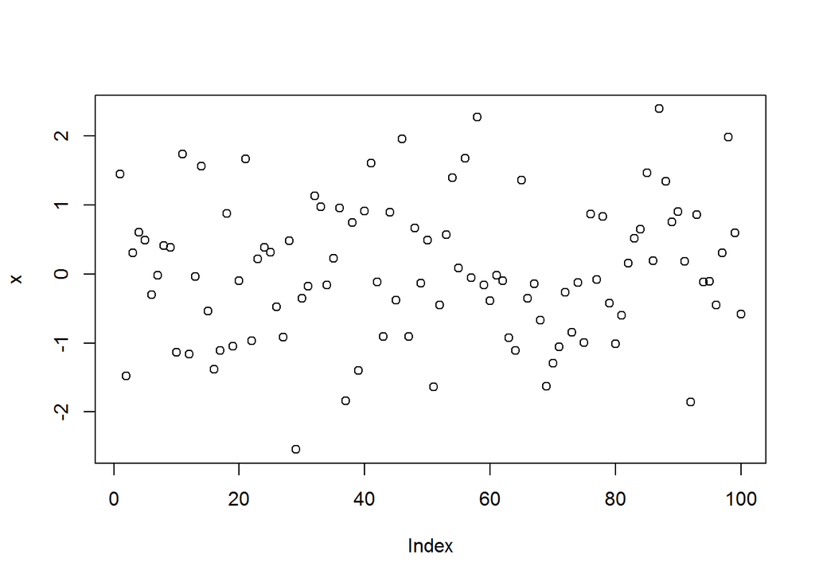

```r
x=rnorm(100)
plot(x)
```

## ToDo 5

Find help for the sqrt function.

```r
help(sqrt)
```

```
## starting httpd help server ...
```

```
##  done
```

```r
#or
?sqrt
```

## ToDo 6

Make a file called firstscript.R containing Rcode that generates 100 random numbers and plots them, and run this script several times.

firstscript.R

```r
#firstscript.R
x=rnorm(100)
plot(x)
```

```r
for (i in 1:3){
  source("firstscript.R")
}
```

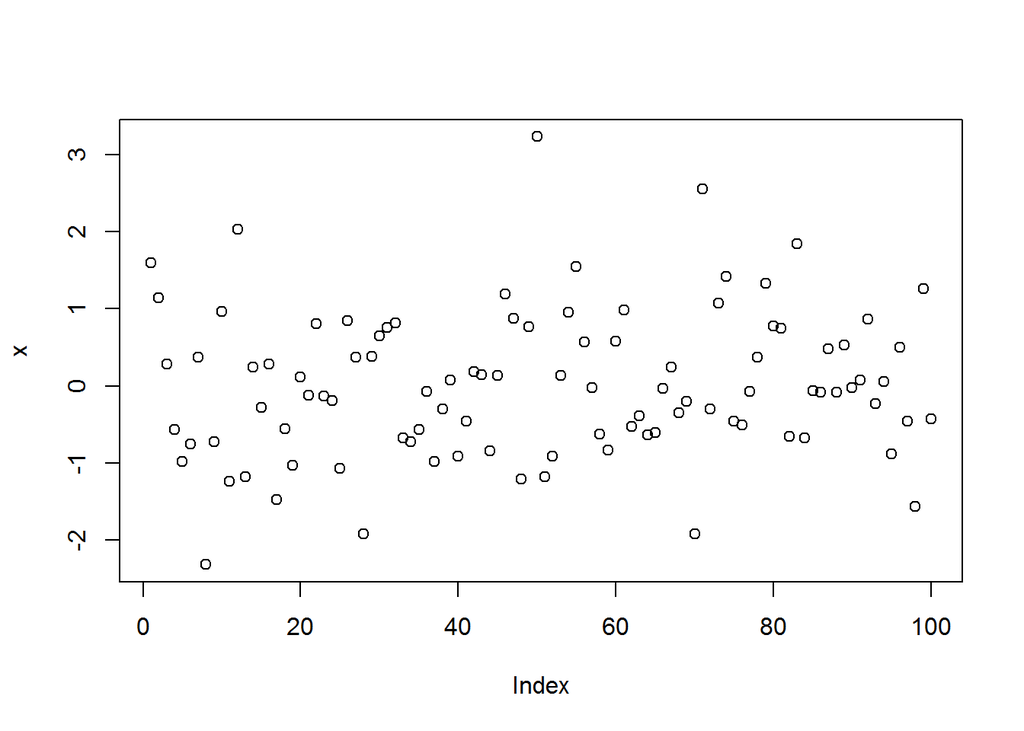

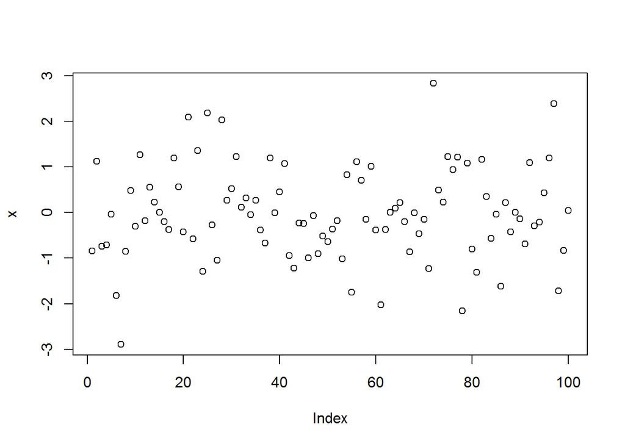

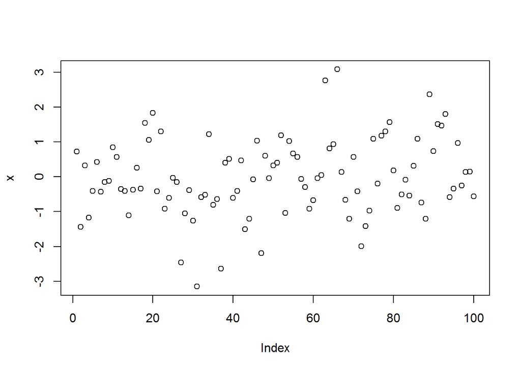

## ToDo 7

Put the numbers 31 to 60 in a vector named P and in a matrix with 6 rows and 5 columns named Q. Tip: use the function seq. Look at the different ways scalars, vectors and matrices are denoted in the workspace window.

```r
P=c(31:60)
Q=matrix(P,nrow=6,ncol=5)
Q
```

```
##      [,1] [,2] [,3] [,4] [,5]
## [1,]   31   37   43   49   55
## [2,]   32   38   44   50   56
## [3,]   33   39   45   51   57
## [4,]   34   40   46   52   58
## [5,]   35   41   47   53   59
## [6,]   36   42   48   54   60
```

## ToDo 8

Make a script file which constructs three random normal vectors of length 100. Call these vectors x1, x2 and x3. Make a data frame called t with three columns (called a, b and c) containing respectively x1, x1+x2 and x1+x2+x3. Call the following functions for this data frame: plot(t) and sd(t). Can you understand the results? Rerun this script a few times.

Note: sd on data.frames has been defunct since R-3.0.0.

ToDo8.R

```r
#ToDo8.R
x1=rnorm(100)
x2=rnorm(100)
x3=rnorm(100)
t=data.frame(a=x1,b=x1+x2,c=x1+x2+x3)

plot(t)
#sd(t)
print(sapply(t,sd))
```

```r
for (i in 1:3){
  source("ToDo8.R")
}
```

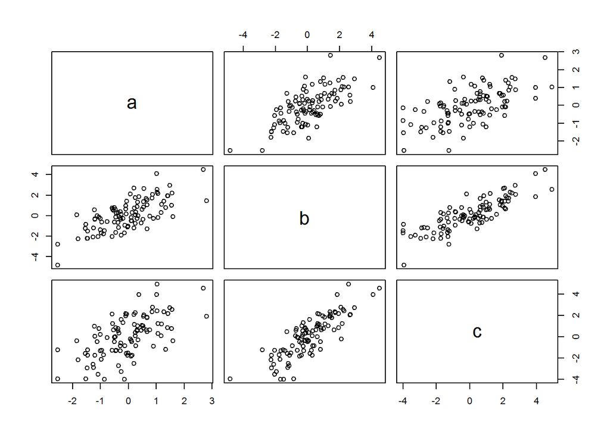

```
##         a         b         c
## 0.9996842 1.5184967 1.9164495
```

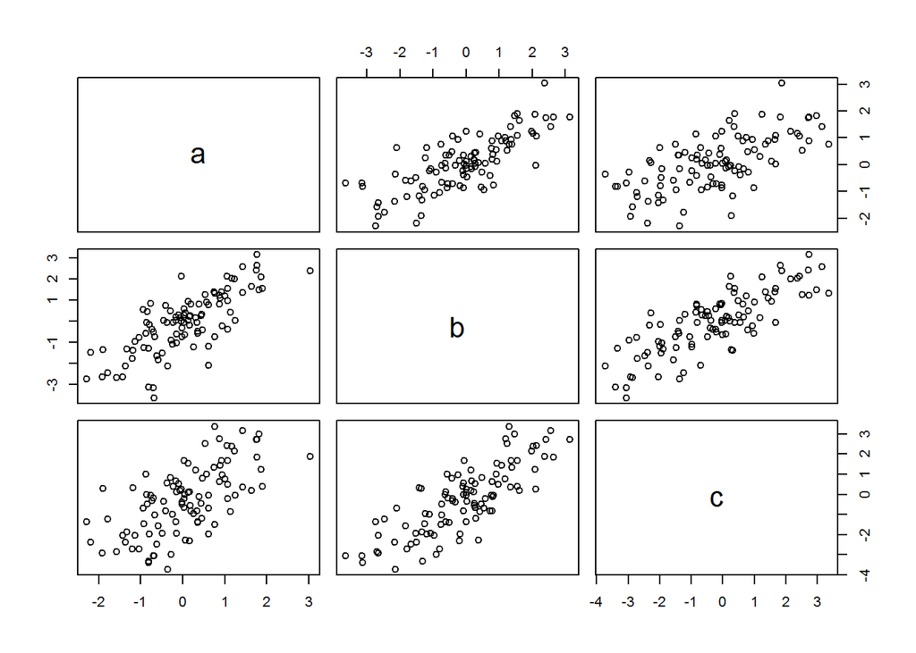

```
##        a        b        c
## 1.007206 1.432332 1.671737
```

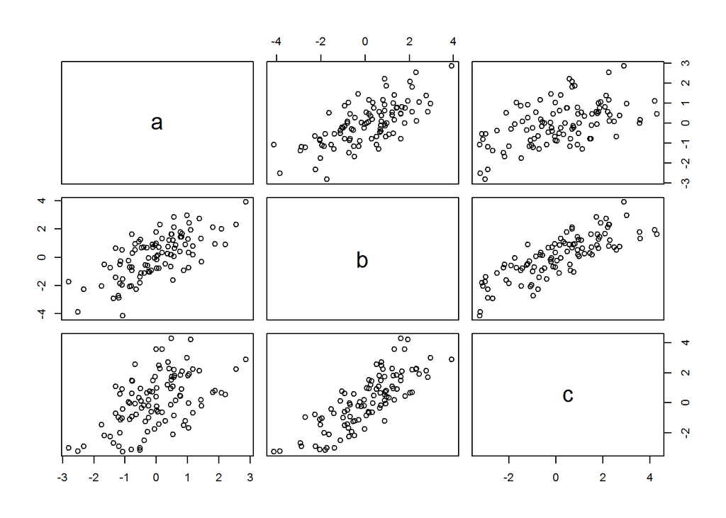

```
##        a        b        c
## 1.046851 1.527499 1.785203
```